# IS 670 Lab 9: Clustering

You have been given a data file by the San Francisco Bay Area Rapid Transit (BART), which identifies a set of demographics for residents in a local area. We will use this file to determine residents segmentations so that we can use it to develop marketing plans accordingly.  
VARIABLE DESCRIPTIONS:  
Age:

```
        1.   14 thru 17
        2.   18 thru 24
        3.   25 thru 34
        4.   35 thru 44
        5.   45 thru 54
        6.   55 thru 64
        7.   65 and Over
```

DistToWork: Distance to work in miles  
DualInc: Is dual income household or not  
Education:

```
        1. Grade 8 or less<br>
        2. Grades 9 to 11<br>
        3. Graduated high school<br>
        4. 1 to 3 years of college<br>
        5. College graduate<br>
        6. Grad Study<br>
```

Gender: M or F  
Income:

```
        1. Less than $10,000<br>
        2. $10,000 to $14,999<br>
        3. $15,000 to $19,999<br>
        4. $20,000 to $24,999<br>
        5. $25,000 to $29,999<br>
        6. $30,000 to $39,999<br>
        7. $40,000 to $49,999<br>
        8. $50,000 to $74,999<br>
        9. $75,000 or more<br>
```

Language: Language spoken at home  
NbrInHouseHold: Number in household  
NbrInHouseholdUnder18: Number in household under 18 years old  
OwnRent: Own, rent, or live with parents  
YrsInArea: Years lived in bay area  
Rider: No, Non-rider; Yes, Rider

### 1. Upload and clean data

```python
# Mounting Google Drive
from google.colab import drive
drive.mount('/content/drive')
```

```python
# Import libraries
import pandas as pd
from sklearn.cluster import KMeans
from collections import Counter
from sklearn import preprocessing
from matplotlib import pyplot as plt
```

```python
# Read data
# Assuming the dataset is uploaded to your 'Colab Notebooks' folder on Google Drive.
BartRider = pd.read_csv("/content/drive/MyDrive/IS 670/BartRider.csv")
BartRider
```

|  | Age | DistToWork | DualInc | Education | Gender | Income | Language | NbrInHouseHold | NbrInHouseholdUnder18 | OwnRent | YrsInArea | Rider |
| --- | --- | --- | --- | --- | --- | --- | --- | --- | --- | --- | --- | --- |
| 0 | 3 | 10 | N | 4 | F | 7 | English | 1 | 0 | Rent | 3 | Yes |
| 1 | 3 | 11 | N | 4 | M | 6 | English | 3 | 1 | Rent | 2 | No |
| 2 | 2 | 10 | N | 5 | M | 6 | English | 2 | 0 | Rent | 3 | No |
| 3 | 5 | 6 | Y | 5 | M | 4 | English | 3 | 0 | Rent | 5 | No |
| 4 | 4 | 9 | N | 4 | F | 4 | English | 3 | 1 | Rent | 4 | No |
| ... | ... | ... | ... | ... | ... | ... | ... | ... | ... | ... | ... | ... |
| 5488 | 2 | 9 | N | 2 | F | 1 | English | 5 | 1 | Parent | 6 | Yes |
| 5489 | 2 | 9 | N | 2 | F | 2 | Other | 4 | 1 | Parent | 4 | Yes |
| 5490 | 1 | 13 | N | 2 | F | 2 | Spanish | 4 | 2 | Parent | 1 | Yes |
| 5491 | 4 | 9 | N | 3 | M | 1 | English | 3 | 2 | Parent | 4 | Yes |
| 5492 | 1 | 10 | N | 3 | F | 5 | Other | 3 | 1 | Parent | 4 | Yes |

5493 rows × 12 columns

```python
# Show the head rows of a data frame
BartRider.head()
```

|  | Age | DistToWork | DualInc | Education | Gender | Income | Language | NbrInHouseHold | NbrInHouseholdUnder18 | OwnRent | YrsInArea | Rider |
| --- | --- | --- | --- | --- | --- | --- | --- | --- | --- | --- | --- | --- |
| 0 | 3 | 10 | N | 4 | F | 7 | English | 1 | 0 | Rent | 3 | Yes |
| 1 | 3 | 11 | N | 4 | M | 6 | English | 3 | 1 | Rent | 2 | No |
| 2 | 2 | 10 | N | 5 | M | 6 | English | 2 | 0 | Rent | 3 | No |
| 3 | 5 | 6 | Y | 5 | M | 4 | English | 3 | 0 | Rent | 5 | No |
| 4 | 4 | 9 | N | 4 | F | 4 | English | 3 | 1 | Rent | 4 | No |

```python
# Examine variable type
BartRider.dtypes
```

|  | 0 |
| --- | --- |
| Age | int64 |
| DistToWork | int64 |
| DualInc | object |
| Education | int64 |
| Gender | object |
| Income | int64 |
| Language | object |
| NbrInHouseHold | int64 |
| NbrInHouseholdUnder18 | int64 |
| OwnRent | object |
| YrsInArea | int64 |
| Rider | object |

**dtype:** object

```python
# Change categorical variables to "category"
BartRider['DualInc'] = BartRider['DualInc'].astype('category')
BartRider['Gender'] = BartRider['Gender'].astype('category')
BartRider['Language'] = BartRider['Language'].astype('category')
BartRider['OwnRent'] = BartRider['OwnRent'].astype('category')
BartRider['Rider'] = BartRider['Rider'].astype('category')
```

```python
# Examine variable type
BartRider.dtypes
```

|  | 0 |
| --- | --- |
| Age | int64 |
| DistToWork | int64 |
| DualInc | category |
| Education | int64 |
| Gender | category |
| Income | int64 |
| Language | category |
| NbrInHouseHold | int64 |
| NbrInHouseholdUnder18 | int64 |
| OwnRent | category |
| YrsInArea | int64 |
| Rider | category |

**dtype:** object

### 2. Prepare data set for clustering

```python
# Create dummy variables
BartRider = pd.get_dummies(BartRider, columns=['DualInc','Gender','Language','OwnRent','Rider'], drop_first=True)
BartRider
```

|  | Age | DistToWork | Education | Income | NbrInHouseHold | NbrInHouseholdUnder18 | YrsInArea | DualInc_Y | Gender_M | Language_Other | Language_Spanish | OwnRent_Parent | OwnRent_Rent | Rider_Yes |
| --- | --- | --- | --- | --- | --- | --- | --- | --- | --- | --- | --- | --- | --- | --- |
| 0 | 3 | 10 | 4 | 7 | 1 | 0 | 3 | False | False | False | False | False | True | True |
| 1 | 3 | 11 | 4 | 6 | 3 | 1 | 2 | False | True | False | False | False | True | False |
| 2 | 2 | 10 | 5 | 6 | 2 | 0 | 3 | False | True | False | False | False | True | False |
| 3 | 5 | 6 | 5 | 4 | 3 | 0 | 5 | True | True | False | False | False | True | False |
| 4 | 4 | 9 | 4 | 4 | 3 | 1 | 4 | False | False | False | False | False | True | False |
| ... | ... | ... | ... | ... | ... | ... | ... | ... | ... | ... | ... | ... | ... | ... |
| 5488 | 2 | 9 | 2 | 1 | 5 | 1 | 6 | False | False | False | False | True | False | True |
| 5489 | 2 | 9 | 2 | 2 | 4 | 1 | 4 | False | False | True | False | True | False | True |
| 5490 | 1 | 13 | 2 | 2 | 4 | 2 | 1 | False | False | False | True | True | False | True |
| 5491 | 4 | 9 | 3 | 1 | 3 | 2 | 4 | False | True | False | False | True | False | True |
| 5492 | 1 | 10 | 3 | 5 | 3 | 1 | 4 | False | False | True | False | True | False | True |

5493 rows × 14 columns

```python
# Apply minmax normalization
min_max_scaler = preprocessing.MinMaxScaler()
BartRider_normalized = pd.DataFrame(min_max_scaler.fit_transform(BartRider))
BartRider_normalized.columns = BartRider.columns
BartRider_normalized
```

|  | Age | DistToWork | Education | Income | NbrInHouseHold | NbrInHouseholdUnder18 | YrsInArea | DualInc_Y | Gender_M | Language_Other | Language_Spanish | OwnRent_Parent | OwnRent_Rent | Rider_Yes |
| --- | --- | --- | --- | --- | --- | --- | --- | --- | --- | --- | --- | --- | --- | --- |
| 0 | 0.333333 | 0.35 | 0.6 | 0.750 | 0.0 | 0.000000 | 0.2 | 0.0 | 0.0 | 0.0 | 0.0 | 0.0 | 1.0 | 1.0 |
| 1 | 0.333333 | 0.40 | 0.6 | 0.625 | 0.4 | 0.333333 | 0.1 | 0.0 | 1.0 | 0.0 | 0.0 | 0.0 | 1.0 | 0.0 |
| 2 | 0.166667 | 0.35 | 0.8 | 0.625 | 0.2 | 0.000000 | 0.2 | 0.0 | 1.0 | 0.0 | 0.0 | 0.0 | 1.0 | 0.0 |
| 3 | 0.666667 | 0.15 | 0.8 | 0.375 | 0.4 | 0.000000 | 0.4 | 1.0 | 1.0 | 0.0 | 0.0 | 0.0 | 1.0 | 0.0 |
| 4 | 0.500000 | 0.30 | 0.6 | 0.375 | 0.4 | 0.333333 | 0.3 | 0.0 | 0.0 | 0.0 | 0.0 | 0.0 | 1.0 | 0.0 |
| ... | ... | ... | ... | ... | ... | ... | ... | ... | ... | ... | ... | ... | ... | ... |
| 5488 | 0.166667 | 0.30 | 0.2 | 0.000 | 0.8 | 0.333333 | 0.5 | 0.0 | 0.0 | 0.0 | 0.0 | 1.0 | 0.0 | 1.0 |
| 5489 | 0.166667 | 0.30 | 0.2 | 0.125 | 0.6 | 0.333333 | 0.3 | 0.0 | 0.0 | 1.0 | 0.0 | 1.0 | 0.0 | 1.0 |
| 5490 | 0.000000 | 0.50 | 0.2 | 0.125 | 0.6 | 0.666667 | 0.0 | 0.0 | 0.0 | 0.0 | 1.0 | 1.0 | 0.0 | 1.0 |
| 5491 | 0.500000 | 0.30 | 0.4 | 0.000 | 0.4 | 0.666667 | 0.3 | 0.0 | 1.0 | 0.0 | 0.0 | 1.0 | 0.0 | 1.0 |
| 5492 | 0.000000 | 0.35 | 0.4 | 0.500 | 0.4 | 0.333333 | 0.3 | 0.0 | 0.0 | 1.0 | 0.0 | 1.0 | 0.0 | 1.0 |

5493 rows × 14 columns

## 3. Clustering model

```python
# Build a clustering model with n_clusters = 2. Set random_state=0.
model1 = KMeans(n_clusters=2, random_state=0)
model1.fit(BartRider_normalized)
```

```
KMeans(n_clusters=2, random_state=0)
```

```python
# Generate the cluster labels
model1.labels_
```

```
array([1, 0, 0, ..., 1, 1, 1], dtype=int32)
```

```python
# Show cluster size
Counter(model1.labels_)
```

```
Counter({np.int32(1): 2185, np.int32(0): 3308})
```

```python
# Show cluster centroids
pd.DataFrame({'cluster 1':BartRider[model1.labels_==0].mean(axis=0), 'cluster 2':BartRider[model1.labels_==1].mean(axis=0)})
```

|  | cluster 1 | cluster 2 |
| --- | --- | --- |
| Age | 4.209190 | 2.375286 |
| DistToWork | 11.487001 | 11.429748 |
| Education | 4.302297 | 3.222426 |
| Income | 6.178960 | 3.605492 |
| NbrInHouseHold | 2.586457 | 3.435698 |
| NbrInHouseholdUnder18 | 0.529625 | 0.981236 |
| YrsInArea | 4.333132 | 4.234783 |
| DualInc_Y | 0.412031 | 0.004577 |
| Gender_M | 0.462817 | 0.450343 |
| Language_Other | 0.025393 | 0.048055 |
| Language_Spanish | 0.058646 | 0.112128 |
| OwnRent_Parent | 0.007255 | 0.633867 |
| OwnRent_Rent | 0.360641 | 0.284668 |
| Rider_Yes | 0.085550 | 0.939130 |

Q1. What is the percentage of BART riders for cluster 1 and 2? (1 point)  
**Answer:**  
For cluster 1, approximately 8.6% of residents are BART riders. For cluster 2, approximately 93.9% of residents are BART riders. This shows a very clear division between the two clusters based on ridership.

Q2. Use the attributes information of cluster centers to understand the profile of residents. Interpret each cluster based on your understanding. (1 point)  
**Answer:**  
Cluster 1 consists of older, wealthier professionals with higher education who own their homes. They rarely ride BART and include more dual-income households. Cluster 2 represents younger, less affluent individuals who live with their parents. They have lower education levels and are highly frequent BART riders.

```python
# Build a clustering model with n_clusters = 3 (0.5 point)
model2 = KMeans(n_clusters=3, random_state=0)
model2.fit(BartRider_normalized)
```

```
KMeans(n_clusters=3, random_state=0)
```

```python
# Generate the cluster labels (0.5 point)
model2.labels_
```

```
array([2, 2, 2, ..., 1, 1, 1], dtype=int32)
```

```python
# Show cluster size (0.5 point)
Counter(model2.labels_)
```

```
Counter({np.int32(2): 1810, np.int32(0): 2293, np.int32(1): 1390})
```

```python
# Show cluster centroids (0.5 point)
pd.DataFrame({'cluster 1':BartRider[model2.labels_==0].mean(axis=0), 'cluster 2':BartRider[model2.labels_==1].mean(axis=0), 'cluster 3':BartRider[model2.labels_==2].mean(axis=0)})
```

|  | cluster 1 | cluster 2 | cluster 3 |
| --- | --- | --- | --- |
| Age | 4.702573 | 1.813669 | 3.209945 |
| DistToWork | 11.447449 | 11.428777 | 11.512707 |
| Education | 4.451810 | 2.761151 | 3.992818 |
| Income | 7.102486 | 2.932374 | 4.395580 |
| NbrInHouseHold | 2.799389 | 3.972662 | 2.277348 |
| NbrInHouseholdUnder18 | 0.634104 | 1.265468 | 0.377348 |
| YrsInArea | 4.610118 | 4.383453 | 3.824862 |
| DualInc_Y | 0.464893 | 0.003597 | 0.166851 |
| Gender_M | 0.404710 | 0.423022 | 0.551934 |
| Language_Other | 0.020497 | 0.061871 | 0.030939 |
| Language_Spanish | 0.045792 | 0.143885 | 0.074033 |
| OwnRent_Parent | 0.010467 | 0.996403 | 0.000000 |
| OwnRent_Rent | 0.002617 | 0.000000 | 0.999448 |
| Rider_Yes | 0.149586 | 0.904317 | 0.406077 |

Q3. Assign a meaningful name to each cluster based on the representative profile of residents in each cluster. Explain the reasons for the name you choose. (1 point)

**Answer:**  
Cluster 1 is "Established Homeowners" because they are older, wealthier, and own their homes. Cluster 2 is "Young Dependents" since they are the youngest, have lower incomes, and live with parents. Cluster 3 is "Working Renters" representing middle aged professionals with moderate incomes who rent their homes.

Q4. Based on the cluster size and centroids, which n_clusters (n_clusters=2 or n_clusters=3) you will use, and why? (1 point)  
**Answer:**  
I will use n_clusters=3 because it provides a more granular and actionable segmentation of the population. While k=2 mostly splits the data by whether they live with parents or not, k=3 successfully separates independent adults into renters and homeowners. This distinction is crucial for developing targeted marketing campaigns.

Q5. If we segment residents into 3 clusters, what marketing plans you can use to target each cluster? (1 point)

**Answer:**  
For "Established Homeowners" we should market premium monthly passes or family discount deals. For "Young Dependents" we can target them with student discounts and social media campaigns about eco-friendly travel. For "Working Renters" we should promote flexible commuter plans and integrate loyalty rewards with local rental communities.

## 4. Elbow test to determine optimal number of clusters

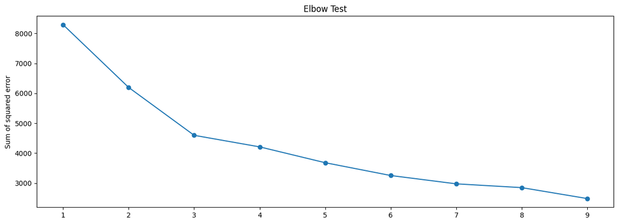

```python
Sum_of_squared_error = []
for k in range(1, 10):
    kmeans = KMeans(n_clusters=k)
    kmeans.fit(BartRider_normalized)
    Sum_of_squared_error.append(kmeans.inertia_)

fig = plt.figure(figsize=(15, 5))
plt.scatter(range(1, 10), Sum_of_squared_error)
plt.plot(range(1, 10), Sum_of_squared_error)
plt.ylabel('Sum of squared error')
plt.title('Elbow Test')
```

Q6. What is the optimal cluster number? (1 point)  
**Answer:**  
Based on the elbow test, the optimal cluster number is 3. The sum of squared errors decreases significantly as k increases from 1 to 3. However, the rate of decrease slows down and flattens out noticeably after reaching k=3.

```python
!jupyter nbconvert --to html "/content/drive/MyDrive/IS 670/IS670_lab09.ipynb"
```

```
[NbConvertApp] Converting notebook /content/drive/MyDrive/IS 670/IS670_lab09.ipynb to html
[NbConvertApp] WARNING | Alternative text is missing on 1 image(s).
[NbConvertApp] Writing 428992 bytes to /content/drive/MyDrive/IS 670/IS670_lab09.html
```